#### Authors : Aarushi Pandey,Karthikeyan Mohan,Robin Chabbra,Yugandhar Kumar Savalam

# Import Packages

```python
import pandas as pd
import numpy as np
import matplotlib.pyplot as plt
```

# Exploratory Data Analysis

#### Load the Dataset

```python
heart_dataset = pd.read_csv('Data\processed.cleveland.data',header=None)
```

#### Display number of rowns and columns

```python
heart_dataset.shape
```

```
(303, 14)
```

#### Display Top 5 Rows

```python
heart_dataset.head()
```

|  | 0 | 1 | 2 | 3 | 4 | 5 | 6 | 7 | 8 | 9 | 10 | 11 | 12 | 13 |
| --- | --- | --- | --- | --- | --- | --- | --- | --- | --- | --- | --- | --- | --- | --- |
| 0 | 63.0 | 1.0 | 1.0 | 145.0 | 233.0 | 1.0 | 2.0 | 150.0 | 0.0 | 2.3 | 3.0 | 0.0 | 6.0 | 0 |
| 1 | 67.0 | 1.0 | 4.0 | 160.0 | 286.0 | 0.0 | 2.0 | 108.0 | 1.0 | 1.5 | 2.0 | 3.0 | 3.0 | 2 |
| 2 | 67.0 | 1.0 | 4.0 | 120.0 | 229.0 | 0.0 | 2.0 | 129.0 | 1.0 | 2.6 | 2.0 | 2.0 | 7.0 | 1 |
| 3 | 37.0 | 1.0 | 3.0 | 130.0 | 250.0 | 0.0 | 0.0 | 187.0 | 0.0 | 3.5 | 3.0 | 0.0 | 3.0 | 0 |
| 4 | 41.0 | 0.0 | 2.0 | 130.0 | 204.0 | 0.0 | 2.0 | 172.0 | 0.0 | 1.4 | 1.0 | 0.0 | 3.0 | 0 |

#### Create an empty dataset and load the dataset with the actual column names.

```python
heart_data= pd.DataFrame()
```

```python
heart_data['Age']=heart_dataset[0]
heart_data['Sex']=heart_dataset[1]
heart_data['cp']=heart_dataset[2]
heart_data['trestbps']=heart_dataset[3]
heart_data['chol']=heart_dataset[4]
heart_data['fbs']=heart_dataset[5]
heart_data['restecg']=heart_dataset[6]
heart_data['thalach']=heart_dataset[7]
heart_data['thalach']=heart_dataset[7]
heart_data['exang']=heart_dataset[8]
heart_data['oldpeak']=heart_dataset[9]
heart_data['slope']=heart_dataset[10]
heart_data['ca']=heart_dataset[11]
heart_data['thal']=heart_dataset[12]
heart_data['num']=heart_dataset[13]
```

```python
heart_data.head()
```

|  | Age | Sex | cp | trestbps | chol | fbs | restecg | thalach | exang | oldpeak | slope | ca | thal | num |
| --- | --- | --- | --- | --- | --- | --- | --- | --- | --- | --- | --- | --- | --- | --- |
| 0 | 63.0 | 1.0 | 1.0 | 145.0 | 233.0 | 1.0 | 2.0 | 150.0 | 0.0 | 2.3 | 3.0 | 0.0 | 6.0 | 0 |
| 1 | 67.0 | 1.0 | 4.0 | 160.0 | 286.0 | 0.0 | 2.0 | 108.0 | 1.0 | 1.5 | 2.0 | 3.0 | 3.0 | 2 |
| 2 | 67.0 | 1.0 | 4.0 | 120.0 | 229.0 | 0.0 | 2.0 | 129.0 | 1.0 | 2.6 | 2.0 | 2.0 | 7.0 | 1 |
| 3 | 37.0 | 1.0 | 3.0 | 130.0 | 250.0 | 0.0 | 0.0 | 187.0 | 0.0 | 3.5 | 3.0 | 0.0 | 3.0 | 0 |
| 4 | 41.0 | 0.0 | 2.0 | 130.0 | 204.0 | 0.0 | 2.0 | 172.0 | 0.0 | 1.4 | 1.0 | 0.0 | 3.0 | 0 |

#### Perform Statistics

```python
heart_data.describe()
```

|  | Age | Sex | cp | trestbps | chol | fbs | restecg | thalach | exang | oldpeak | slope | num |
| --- | --- | --- | --- | --- | --- | --- | --- | --- | --- | --- | --- | --- |
| count | 303.000000 | 303.000000 | 303.000000 | 303.000000 | 303.000000 | 303.000000 | 303.000000 | 303.000000 | 303.000000 | 303.000000 | 303.000000 | 303.000000 |
| mean | 54.438944 | 0.679868 | 3.158416 | 131.689769 | 246.693069 | 0.148515 | 0.990099 | 149.607261 | 0.326733 | 1.039604 | 1.600660 | 0.937294 |
| std | 9.038662 | 0.467299 | 0.960126 | 17.599748 | 51.776918 | 0.356198 | 0.994971 | 22.875003 | 0.469794 | 1.161075 | 0.616226 | 1.228536 |
| min | 29.000000 | 0.000000 | 1.000000 | 94.000000 | 126.000000 | 0.000000 | 0.000000 | 71.000000 | 0.000000 | 0.000000 | 1.000000 | 0.000000 |
| 25% | 48.000000 | 0.000000 | 3.000000 | 120.000000 | 211.000000 | 0.000000 | 0.000000 | 133.500000 | 0.000000 | 0.000000 | 1.000000 | 0.000000 |
| 50% | 56.000000 | 1.000000 | 3.000000 | 130.000000 | 241.000000 | 0.000000 | 1.000000 | 153.000000 | 0.000000 | 0.800000 | 2.000000 | 0.000000 |
| 75% | 61.000000 | 1.000000 | 4.000000 | 140.000000 | 275.000000 | 0.000000 | 2.000000 | 166.000000 | 1.000000 | 1.600000 | 2.000000 | 2.000000 |
| max | 77.000000 | 1.000000 | 4.000000 | 200.000000 | 564.000000 | 1.000000 | 2.000000 | 202.000000 | 1.000000 | 6.200000 | 3.000000 | 4.000000 |

#### Perform statistic for Object datatype

```python
heart_data.describe(include = object)
```

|  | ca | thal |
| --- | --- | --- |
| count | 303 | 303 |
| unique | 5 | 4 |
| top | 0.0 | 3.0 |
| freq | 176 | 166 |

#### Find the correlation between the data.

```python
heart_data.corr()
```

|  | Age | Sex | cp | trestbps | chol | fbs | restecg | thalach | exang | oldpeak | slope | num |
| --- | --- | --- | --- | --- | --- | --- | --- | --- | --- | --- | --- | --- |
| Age | 1.000000 | -0.097542 | 0.104139 | 0.284946 | 0.208950 | 0.118530 | 0.148868 | -0.393806 | 0.091661 | 0.203805 | 0.161770 | 0.222853 |
| Sex | -0.097542 | 1.000000 | 0.010084 | -0.064456 | -0.199915 | 0.047862 | 0.021647 | -0.048663 | 0.146201 | 0.102173 | 0.037533 | 0.224469 |
| cp | 0.104139 | 0.010084 | 1.000000 | -0.036077 | 0.072319 | -0.039975 | 0.067505 | -0.334422 | 0.384060 | 0.202277 | 0.152050 | 0.407075 |
| trestbps | 0.284946 | -0.064456 | -0.036077 | 1.000000 | 0.130120 | 0.175340 | 0.146560 | -0.045351 | 0.064762 | 0.189171 | 0.117382 | 0.157754 |
| chol | 0.208950 | -0.199915 | 0.072319 | 0.130120 | 1.000000 | 0.009841 | 0.171043 | -0.003432 | 0.061310 | 0.046564 | -0.004062 | 0.070909 |
| fbs | 0.118530 | 0.047862 | -0.039975 | 0.175340 | 0.009841 | 1.000000 | 0.069564 | -0.007854 | 0.025665 | 0.005747 | 0.059894 | 0.059186 |
| restecg | 0.148868 | 0.021647 | 0.067505 | 0.146560 | 0.171043 | 0.069564 | 1.000000 | -0.083389 | 0.084867 | 0.114133 | 0.133946 | 0.183696 |
| thalach | -0.393806 | -0.048663 | -0.334422 | -0.045351 | -0.003432 | -0.007854 | -0.083389 | 1.000000 | -0.378103 | -0.343085 | -0.385601 | -0.415040 |
| exang | 0.091661 | 0.146201 | 0.384060 | 0.064762 | 0.061310 | 0.025665 | 0.084867 | -0.378103 | 1.000000 | 0.288223 | 0.257748 | 0.397057 |
| oldpeak | 0.203805 | 0.102173 | 0.202277 | 0.189171 | 0.046564 | 0.005747 | 0.114133 | -0.343085 | 0.288223 | 1.000000 | 0.577537 | 0.504092 |
| slope | 0.161770 | 0.037533 | 0.152050 | 0.117382 | -0.004062 | 0.059894 | 0.133946 | -0.385601 | 0.257748 | 0.577537 | 1.000000 | 0.377957 |
| num | 0.222853 | 0.224469 | 0.407075 | 0.157754 | 0.070909 | 0.059186 | 0.183696 | -0.415040 | 0.397057 | 0.504092 | 0.377957 | 1.000000 |

#### Check if any NULL Value is present

```python
heart_data.isnull().sum()
```

```
Age         0
Sex         0
cp          0
trestbps    0
chol        0
fbs         0
restecg     0
thalach     0
exang       0
oldpeak     0
slope       0
ca          0
thal        0
num         0
dtype: int64
```

# Data Vizualisation

#### we wanted to explore new tools and hence we used Power BI to vizualise the data.

#### Power BI Report Link:'https://app.powerbi.com/groups/me/reports/d01aab17-ece2-4f97-ac04-a186a81219ee/ReportSection'

#### Below is the screenshot of the same.

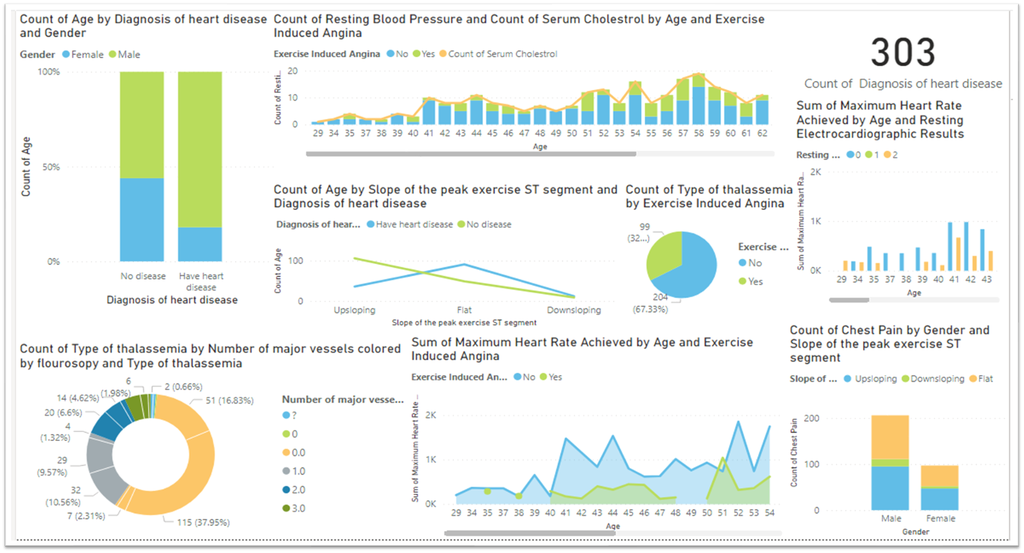

```python
from IPython.display import Image
Image(filename='Power BI - Vizualisation/Heart_data_PowerBI.PNG')
```

# Data Cleanup

```python
print(heart_data['ca'].value_counts())
print(heart_data['thal'].value_counts())
```

```
0.0    176
1.0     65
2.0     38
3.0     20
?        4
Name: ca, dtype: int64
3.0    166
7.0    117
6.0     18
?        2
Name: thal, dtype: int64
```

#### We dont have Null values, but we have '?' value present in two fields. We are using Mode to fill the '?'.

```python
heart_data['ca'] = heart_data['ca'].replace('\?',np.NaN, regex=True)
heart_data['thal'] = heart_data['thal'].replace('\?',np.NaN, regex=True)
```

```python
print(heart_data['ca'].value_counts())
print(heart_data['thal'].value_counts())
```

```
0.0    176
1.0     65
2.0     38
3.0     20
Name: ca, dtype: int64
3.0    166
7.0    117
6.0     18
Name: thal, dtype: int64
```

```python
heart_data.isnull().sum()
```

```
Age         0
Sex         0
cp          0
trestbps    0
chol        0
fbs         0
restecg     0
thalach     0
exang       0
oldpeak     0
slope       0
ca          4
thal        2
num         0
dtype: int64
```

```python
heart_data['ca'].fillna(heart_data['ca'].mode()[0],inplace=True)
heart_data['thal'].fillna(heart_data['thal'].mode()[0],inplace=True)
```

```python
print(heart_data['ca'].value_counts())
print(heart_data['thal'].value_counts())
```

```
0.0    180
1.0     65
2.0     38
3.0     20
Name: ca, dtype: int64
3.0    168
7.0    117
6.0     18
Name: thal, dtype: int64
```

```python
heart_data.isnull().sum()
```

```
Age         0
Sex         0
cp          0
trestbps    0
chol        0
fbs         0
restecg     0
thalach     0
exang       0
oldpeak     0
slope       0
ca          0
thal        0
num         0
dtype: int64
```

#### Missing value has been taken care of. We have to update the target variable to just 0 and 1

#### 1,2,3 and 4 means Heart disease. So we are updating all 2,3 and 4 to 1.

```python
heart_data['num'].value_counts()
```

```
0    164
1     55
2     36
3     35
4     13
Name: num, dtype: int64
```

```python
heart_data['num'] = heart_data['num'].replace(2,1, regex=True)
heart_data['num'] = heart_data['num'].replace(3,1, regex=True)
heart_data['num'] = heart_data['num'].replace(4,1, regex=True)
```

```python
heart_data['num'].value_counts()
```

```
0    164
1    139
Name: num, dtype: int64
```

# Feature Engineering

#### Assign the values to X and Y set for model to take as an input

```python
X = heart_data.iloc[:,:-1].values
Y = heart_data.iloc[:,-1].values
```

#### Split the Test and Train with 80:20 ratio

```python
from sklearn.model_selection import train_test_split
x_train,x_test,y_train,y_test = train_test_split(X,Y,test_size=0.2,random_state=0)
```

# Model Building

#### We have the classification problem with the target value. we need used the classification alogorithm.

#### 1. Logistic Regression

```python
from sklearn.linear_model import LogisticRegression
from sklearn.metrics import accuracy_score
model = LogisticRegression()
model.fit(x_train,y_train)
```

```
LogisticRegression()
```

#### Feeding the Test data into our model to predict the output

```python
test_prediction = model.predict(x_test)
```

#### Display the predicted output of test data

```python
test_prediction
```

```
array([0, 0, 1, 0, 0, 1, 1, 1, 1, 0, 1, 0, 1, 1, 0, 0, 1, 0, 0, 0, 0, 0,
       0, 1, 0, 0, 0, 1, 1, 1, 0, 0, 0, 1, 1, 0, 0, 0, 0, 0, 0, 1, 1, 0,
       0, 0, 0, 0, 0, 0, 1, 0, 0, 0, 0, 0, 1, 0, 0, 1, 0], dtype=int64)
```

#### Display the actual output values of test data

```python
y_test
```

```
array([0, 0, 1, 0, 1, 1, 1, 1, 1, 0, 1, 0, 0, 1, 0, 1, 1, 0, 0, 0, 1, 0,
       0, 1, 0, 0, 0, 1, 1, 1, 0, 0, 0, 1, 1, 0, 0, 0, 1, 0, 0, 0, 0, 1,
       0, 1, 0, 1, 1, 0, 1, 0, 0, 0, 1, 0, 1, 0, 0, 1, 0], dtype=int64)
```

#### Compare the actual output and predicted output and find the accurary of our model.

```python
accuracy_score(y_test,test_prediction)
```

```
0.8032786885245902
```

#### 2. Naive Bayes Alogorithm

```python
from sklearn.naive_bayes import GaussianNB
nb_model = GaussianNB()
nb_model.fit(x_train, y_train)
```

```
GaussianNB()
```

#### Feed the test data to our model to predict the output value

```python
naive_pred = nb_model.predict(x_test)
```

#### Compre the actual value and the predicted value to find the accuracy

```python
accuracy_score(y_test,naive_pred)
```

```
0.7868852459016393
```

### 3 . Support Vector Machine model

```python
from sklearn.svm import SVC
svc_model = SVC(kernel = 'rbf')
svc_model.fit(x_train, y_train)
```

```
SVC()
```

#### Feed the test data to our model to predict the output value

```python
svc_pred = svc_model.predict(x_test)
```

#### Compre the actual value and the predicted value to find the accuracy

```python
accuracy_score(y_test,svc_pred)
```

```
0.5737704918032787
```

#### From the three classsification algorithm we used, we have find out that Logistic regression gives the better accuracy.

#### Implement the model with the sample input receiving from the user.

```python
manual_input = [[67,1,4,160,286,0,2,108,1,1.5,2,3,3]] #13 inputs from the user
manual_input=np.array(manual_input, dtype=np.float32) # Converting to float to apply it to the model
result = model.predict(manual_input) # Predict the output
print(result) # Display the output
```

```
[1]
```

#### We are making our model as a web application using Flask and make it easier for users to access,provide the inputs and use it.

#### Then we are going to host our website using the EC2 AWS Service

```python
import pickle
file = open('heart_disease_prediction.pkl', 'wb') # Zipping our script into a pkl file to use as a web application
pickle.dump(model, file)
```

#### We have successfully created a wep page and hosted it in the AWS server.

#### URL : http://ec2-18-223-21-172.us-east-2.compute.amazonaws.com:8080/

#### Note : The server will be started and showcased in our presentation.

#### We have attached screenshot of our website in the report.

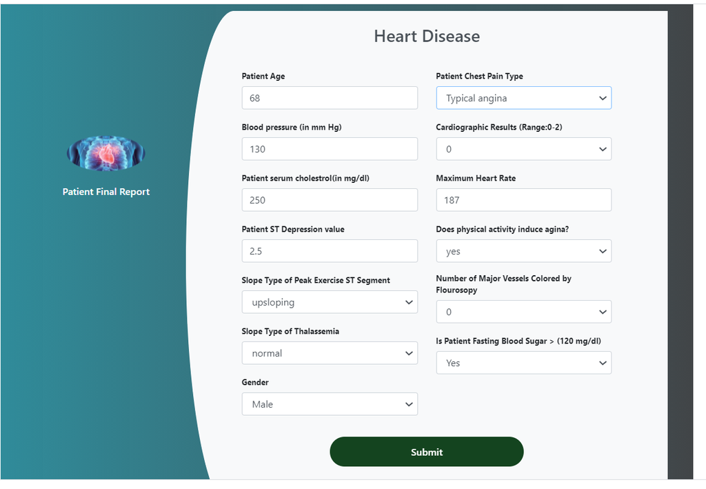

```python
from IPython.display import Image
Image(filename='heart_disease_webpage.PNG')
```